# bellabeats_capstone_casestudy

Anthony

1/30/2022

## Case Study

**Bellabeat** Wellness tracker. Bellabeat is a high-tech manufacturer of health-focused products for women. The *marketing analytics team* whould like to understand the performance of their product and customer response to product changes and improvement efforts.

### Business task:

We want to discover how consumers use non-Bellabeat smart devices, and how we can improve a device to fit the useabilities and performance of similar products.

### Importing R packages

The R packages contain neccessary functions for executing the analysis

```r
library(tidyverse)
library(lubridate)
```

```r
library(dplyr)
library(ggplot2)
library(tidyr)
library(readr)
```

### Getting the Datasets

The dataset was sourced and validated according to my report [here](https://github.com/AntonAIG/google_da_capstone/blob/main/reports/bellabeat_report.md)

```r
activity <- read_csv("/cloud/project/bellabeat_case_study/dailyActivity_merged.csv")
intensities <- read_csv("/cloud/project/bellabeat_case_study/hourlyIntensities_merged.csv")
calories <- read_csv("/cloud/project/bellabeat_case_study/dailyCalories_merged.csv")
sleep <- read_csv("/cloud/project/bellabeat_case_study/sleepDay_merged.csv")
weight <- read_csv("/cloud/project/bellabeat_case_study/weightLogInfo_merged.csv")
```

A quick view of a dataset:

```r
head(weight)
```

```
## # A tibble: 6 × 8
##           Id Date      WeightKg WeightPounds   Fat   BMI IsManualReport    LogId
##        <dbl> <chr>        <dbl>        <dbl> <dbl> <dbl> <lgl>             <dbl>
## 1 1503960366 5/2/2016…     52.6         116.    22  22.6 TRUE            1.46e12
## 2 1503960366 5/3/2016…     52.6         116.    NA  22.6 TRUE            1.46e12
## 3 1927972279 4/13/201…    134.          294.    NA  47.5 FALSE           1.46e12
## 4 2873212765 4/21/201…     56.7         125.    NA  21.5 TRUE            1.46e12
## 5 2873212765 5/12/201…     57.3         126.    NA  21.7 TRUE            1.46e12
## 6 4319703577 4/17/201…     72.4         160.    25  27.5 TRUE            1.46e12
```

### Processing the data

##### Formating

The date columns were processed further and split into date and time columns

```r
intensities$ActivityHour = as.POSIXct(intensities$ActivityHour,
                                      format="%m/%d/%Y %H:%M:%S %p",
                                      tz=Sys.timezone())
intensities$time <- format(intensities$ActivityHour,
                           format="%H:%M:%S")
intensities$date <- format(intensities$ActivityHour,
                           format="%m/%d/%y")
#calories date and time formatting
calories$ActivityDay = as.POSIXct(calories$ActivityDay,
                                 format="%m/%d/%Y %I:%M:%S %p",
                                 tz=Sys.timezone())
calories$time <- format(calories$ActivityDay, format = "%H:%M:%S")
calories$date <- format(calories$ActivityDay, format = "%m/%d/%y")
#activities date and time formatting
activity$ActivityDate = as.POSIXct(activity$ActivityDate,
                                   format="%m/%d/%Y",
                                   tz=Sys.timezone())
activity$date <- format(activity$ActivityDate, format = "%m/%d/%y")
#sleep date formatting
sleep$SleepDay = as.POSIXct(sleep$SleepDay,
                            format="%m/%d/%Y %I:%M:%S %p",
                            tz=Sys.timezone())
sleep$date <- format(sleep$SleepDay, format = "%m/%d/%y")
```

##### Summary statistics

```r
name <- c("activity","calories","intensities","sleep","weight")
activity1 <- n_distinct(activity$Id)
calories1 <- n_distinct(calories$Id)
intensities1 <- n_distinct(intensities$Id)
sleep1 <- n_distinct(sleep$Id)
weight1 <- n_distinct(weight$Id)
unique_count <- c(activity1, calories1, intensities1, sleep1, weight1)
unique_df <- data.frame(name,unique_count)
```

We can observe from the summary statistics that most of the 33 participants were lightly active

```r
## additional summary statistics
#activity
activity %>%
  select(TotalSteps, TotalDistance, SedentaryMinutes, Calories) %>% summary()
```

```
##    TotalSteps    TotalDistance    SedentaryMinutes    Calories
##  Min.   :    0   Min.   : 0.000   Min.   :   0.0   Min.   :   0
##  1st Qu.: 3790   1st Qu.: 2.620   1st Qu.: 729.8   1st Qu.:1828
##  Median : 7406   Median : 5.245   Median :1057.5   Median :2134
##  Mean   : 7638   Mean   : 5.490   Mean   : 991.2   Mean   :2304
##  3rd Qu.:10727   3rd Qu.: 7.713   3rd Qu.:1229.5   3rd Qu.:2793
##  Max.   :36019   Max.   :28.030   Max.   :1440.0   Max.   :4900
```

```r
# number of active minutes per category
activity %>%
  select(VeryActiveMinutes, FairlyActiveMinutes, LightlyActiveMinutes) %>%
  summary()
```

```
##  VeryActiveMinutes FairlyActiveMinutes LightlyActiveMinutes
##  Min.   :  0.00    Min.   :  0.00      Min.   :  0.0
##  1st Qu.:  0.00    1st Qu.:  0.00      1st Qu.:127.0
##  Median :  4.00    Median :  6.00      Median :199.0
##  Mean   : 21.16    Mean   : 13.56      Mean   :192.8
##  3rd Qu.: 32.00    3rd Qu.: 19.00      3rd Qu.:264.0
##  Max.   :210.00    Max.   :143.00      Max.   :518.0
```

```r
#summary statistics of calories
calories %>% select(Calories) %>% summary()
```

```
##     Calories
##  Min.   :   0
##  1st Qu.:1828
##  Median :2134
##  Mean   :2304
##  3rd Qu.:2793
##  Max.   :4900
```

```r
#summary statistics of sleep
sleep %>% select(TotalSleepRecords, TotalMinutesAsleep, TotalTimeInBed) %>%
  summary()
```

```
##  TotalSleepRecords TotalMinutesAsleep TotalTimeInBed
##  Min.   :1.000     Min.   : 58.0      Min.   : 61.0
##  1st Qu.:1.000     1st Qu.:361.0      1st Qu.:403.0
##  Median :1.000     Median :433.0      Median :463.0
##  Mean   :1.119     Mean   :419.5      Mean   :458.6
##  3rd Qu.:1.000     3rd Qu.:490.0      3rd Qu.:526.0
##  Max.   :3.000     Max.   :796.0      Max.   :961.0
```

```r
#summary statistics of weight
weight %>% select(WeightKg, BMI) %>% summary()
```

```
##     WeightKg           BMI
##  Min.   : 52.60   Min.   :21.45
##  1st Qu.: 61.40   1st Qu.:23.96
##  Median : 62.50   Median :24.39
##  Mean   : 72.04   Mean   :25.19
##  3rd Qu.: 85.05   3rd Qu.:25.56
##  Max.   :133.50   Max.   :47.54
```

The dataset was futher processed in RStudio. Further summary statistics was carried out here to understand the relationships in the features of our dataset.

- We can observe from the summary statistics that most of the 33 participants were lightly active
- The average sleep per participant was 7 hours.
- The average duration spent in sedentary lifestyle is 991 minutes. It’s important for Bellabeats to suggest possible ways of reducing this to their customers.
- With an average number of steps at 7638 per day, this number is lower than the recommended number of 10000 by the WHO. At this number, the customers would have to move about more, either by going for a walk or by jogging.

##### Data merging

```r
data_merged <- merge(sleep, activity, by=c('Id', 'date'))
head(data_merged)
```

```
##           Id     date   SleepDay TotalSleepRecords TotalMinutesAsleep
## 1 1503960366 04/12/16 2016-04-12                 1                327
## 2 1503960366 04/13/16 2016-04-13                 2                384
## 3 1503960366 04/15/16 2016-04-15                 1                412
## 4 1503960366 04/16/16 2016-04-16                 2                340
## 5 1503960366 04/17/16 2016-04-17                 1                700
## 6 1503960366 04/19/16 2016-04-19                 1                304
##   TotalTimeInBed ActivityDate TotalSteps TotalDistance TrackerDistance
## 1            346   2016-04-12      13162          8.50            8.50
## 2            407   2016-04-13      10735          6.97            6.97
## 3            442   2016-04-15       9762          6.28            6.28
## 4            367   2016-04-16      12669          8.16            8.16
## 5            712   2016-04-17       9705          6.48            6.48
## 6            320   2016-04-19      15506          9.88            9.88
##   LoggedActivitiesDistance VeryActiveDistance ModeratelyActiveDistance
```

[output cut: 20 more lines]

### Sharing and Visualization

Three relationships were explored:

**Relationship between total daily calories and the total daily steps taken**

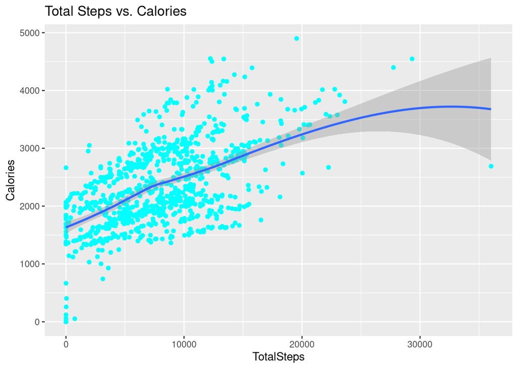

```r
ggplot(data=activity, aes(x=TotalSteps, y=Calories)) +
  geom_point(color='cyan') + geom_smooth() +
  labs(title="Total Steps vs. Calories")
```

From this figure, we can see that there is a positive correlation between Total steps and Calories. Therefore, the more active we are, the more we burn calories.

**Relationship between the total minutes asleep and the total time in bed**

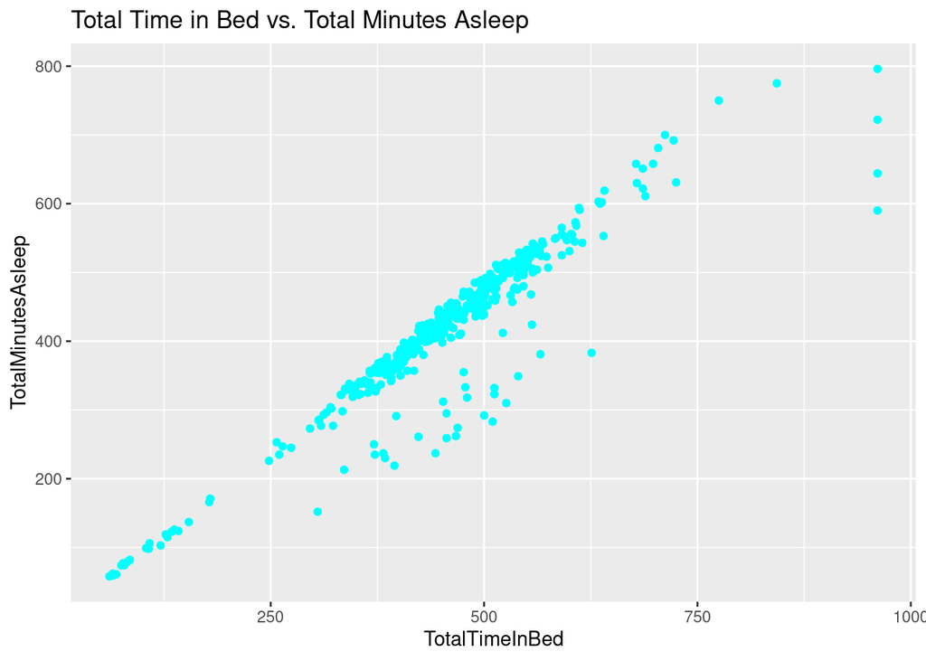

```r
ggplot(data=sleep, aes(x=TotalTimeInBed, y=TotalMinutesAsleep)) +
  geom_point(color='cyan') + labs(title="Total Time in Bed vs. Total Minutes Asleep")
```

This linear relationship shows that more time in bed leads to more sleep.

**Relationship between the total minutes asleep and the total minutes of sedentary living**

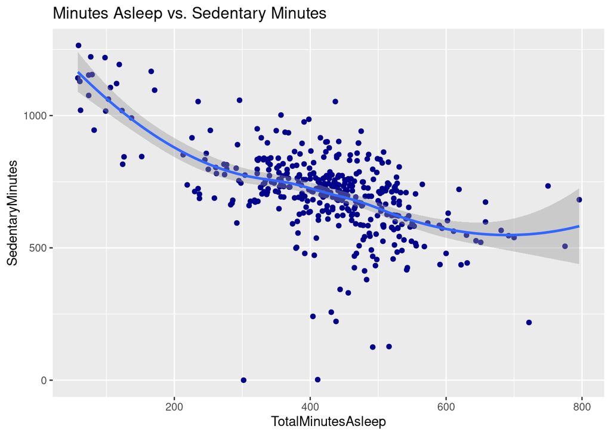

```r
ggplot(data=data_merged, aes(x=TotalMinutesAsleep, y=SedentaryMinutes)) +
  geom_point(color='darkblue') + geom_smooth() +
  labs(title="Minutes Asleep vs. Sedentary Minutes")
```

Here we can clearly see the negative relationship between Sedentary Minutes and Sleep time.

### Conclusion and recommendations

Thanks a lot for going through this analysis.